# SUSENAS Jawa Barat 2023: Showcase Analysis Templates

Analisis Kesejahteraan Rumah Tangga Berbasis SQLite, Tidyverse, dan ggplot2

Author

SUSENAS Research Agent

Published

September 4, 2026

```r
library(DBI)
library(RSQLite)
library(dplyr)
library(ggplot2)
library(forcats)
library(scales)

# Load reusable analysis templates
source(if (file.exists("R/frequency_template.R")) "R/frequency_template.R" else "../R/frequency_template.R")
source(if (file.exists("R/proportion_template.R")) "R/proportion_template.R" else "../R/proportion_template.R")
source(if (file.exists("R/cross_tab_template.R")) "R/cross_tab_template.R" else "../R/cross_tab_template.R")
source(if (file.exists("R/trend_template.R")) "R/trend_template.R" else "../R/trend_template.R")
source(if (file.exists("R/boxplot_template.R")) "R/boxplot_template.R" else "../R/boxplot_template.R")
source(if (file.exists("R/barplot_template.R")) "R/barplot_template.R" else "../R/barplot_template.R")
source(if (file.exists("R/histogram_template.R")) "R/histogram_template.R" else "../R/histogram_template.R")
```

# 1 Pendahuluan

Laporan ini mendemonstrasikan eksekusi 7 modul template visualisasi dan analisis reproducible untuk data SUSENAS Jawa Barat. Seluruh analisis mematuhi arsitektur: 1. **SQLite Aggregation First**: Pengurangan dimensi data dan penghitungan bobot dilakukan di SQLite. 2. **Tidyverse Post-Processing**: Pemberian label metadata resmi BPS dan pemformatan data. 3. **ggplot2 Publication-Ready**: Visualisasi bergaya resmi standar BPS dengan `theme_minimal()`.

# 2 Frequency Analysis (`frequency_template.R`)

Visualisasi distribusi frekuensi jenjang pendidikan tertinggi kepala rumah tangga (KRT).

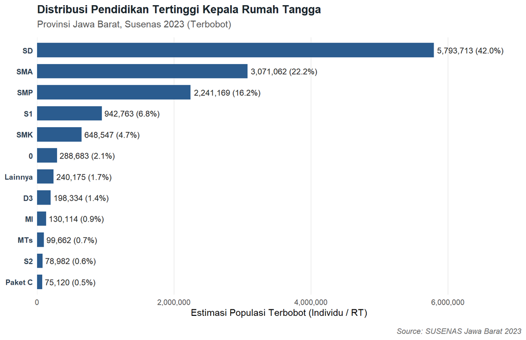

```r
analyze_frequency(
  var = "PENDIDIKAN_TERTINGGI_KRT",
  table = "v_head_household_welfare_2023",
  year = 2023,
  top_n = 12,
  title = "Distribusi Pendidikan Tertinggi Kepala Rumah Tangga",
  subtitle = "Provinsi Jawa Barat, Susenas 2023 (Terbobot)"
)
```

# 3 Proportion Analysis (`proportion_template.R`)

Proporsi klasifikasi wilayah tempat tinggal rumah tangga (Perkotaan vs Perdesaan).

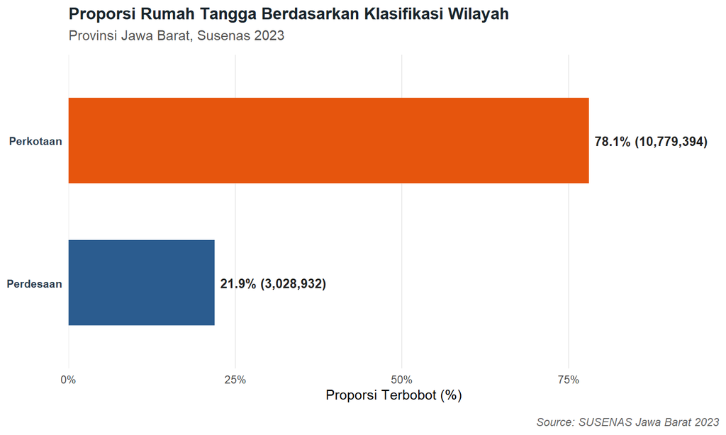

```r
analyze_proportion(
  var = "KLASIFIKASI_PERKOTAAN_PERDESAAN",
  table = "v_head_household_welfare_2023",
  year = 2023,
  chart_type = "bar",
  title = "Proporsi Rumah Tangga Berdasarkan Klasifikasi Wilayah",
  subtitle = "Provinsi Jawa Barat, Susenas 2023"
)
```

# 4 Cross-Tabulation Analysis (`cross_tab_template.R`)

Tabulasi silang antara klasifikasi wilayah tempat tinggal dan status perkawinan kepala rumah tangga.

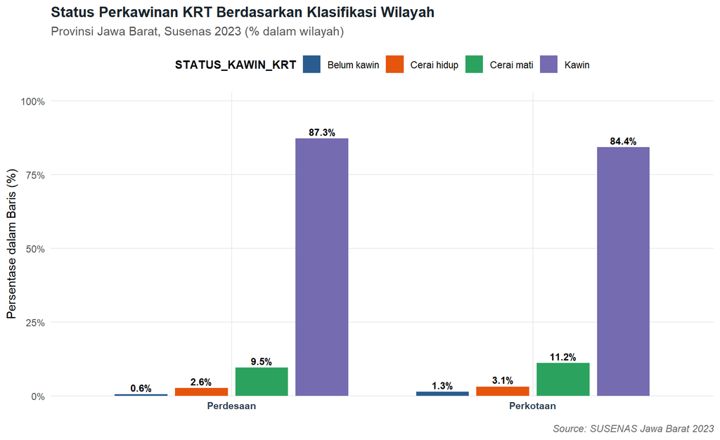

```r
analyze_crosstab(
  var_row = "KLASIFIKASI_PERKOTAAN_PERDESAAN",
  var_col = "STATUS_KAWIN_KRT",
  normalize = "row",
  position = "dodge",
  title = "Status Perkawinan KRT Berdasarkan Klasifikasi Wilayah",
  subtitle = "Provinsi Jawa Barat, Susenas 2023 (% dalam wilayah)"
)
```

# 5 Multi-Year Trend Analysis (`trend_template.R`)

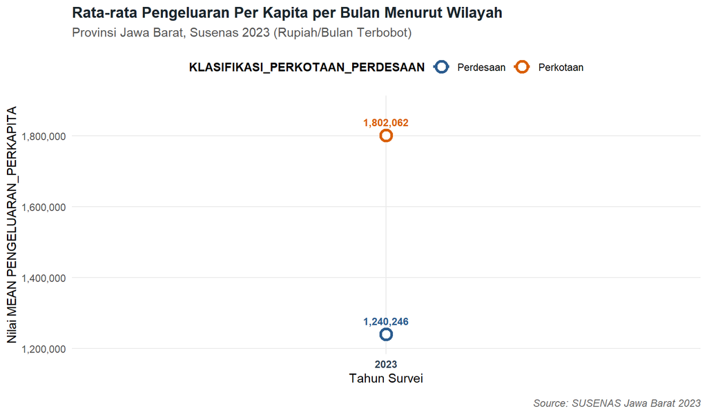

```r
analyze_trend(
  metric_col = "PENGELUARAN_PERKAPITA",
  metric_func = "mean",
  group_var = "KLASIFIKASI_PERKOTAAN_PERDESAAN",
  years = c(2023),
  title = "Rata-rata Pengeluaran Per Kapita per Bulan Menurut Wilayah",
  subtitle = "Provinsi Jawa Barat, Susenas 2023 (Rupiah/Bulan Terbobot)"
)
```

# 6 Boxplot Distribution Analysis (`boxplot_template.R`)

Sebaran pengeluaran per kapita rumah tangga pada skala logaritmik untuk membandingkan disparitas perkotaan dan perdesaan.

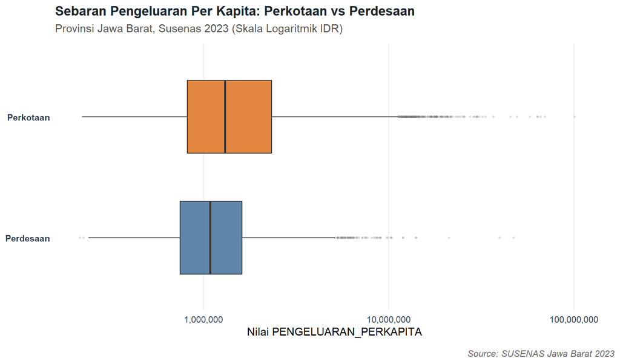

```r
analyze_boxplot(
  num_var = "PENGELUARAN_PERKAPITA",
  group_var = "KLASIFIKASI_PERKOTAAN_PERDESAAN",
  log_scale = TRUE,
  title = "Sebaran Pengeluaran Per Kapita: Perkotaan vs Perdesaan",
  subtitle = "Provinsi Jawa Barat, Susenas 2023 (Skala Logaritmik IDR)"
)
```

# 7 Ranked Barplot Analysis (`barplot_template.R`)

Peringkat 10 kabupaten/kota dengan rata-rata pengeluaran per kapita bulanan tertinggi di Jawa Barat.

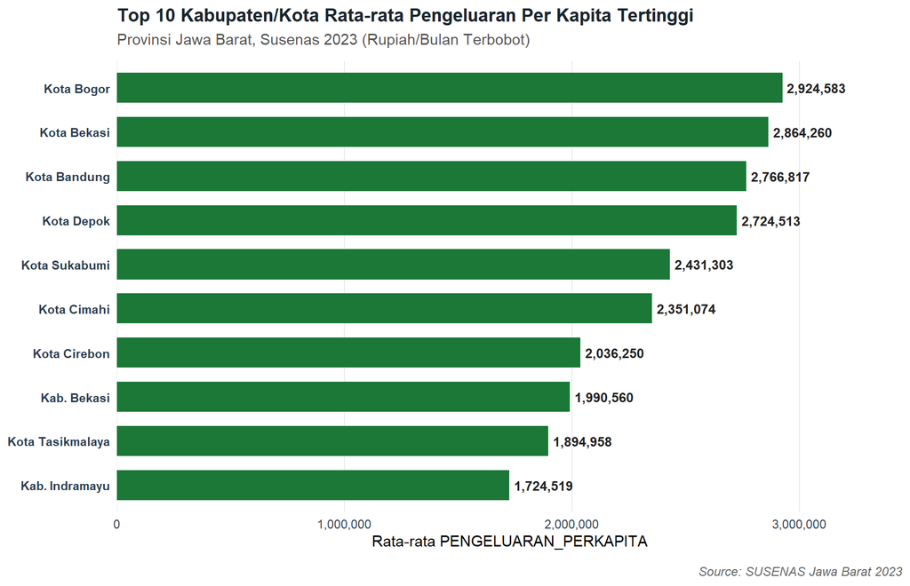

```r
analyze_barplot(
  cat_var = "KODE_KABKOT",
  num_var = "PENGELUARAN_PERKAPITA",
  stat = "mean",
  top_n = 10,
  horizontal = TRUE,
  title = "Top 10 Kabupaten/Kota Rata-rata Pengeluaran Per Kapita Tertinggi",
  subtitle = "Provinsi Jawa Barat, Susenas 2023 (Rupiah/Bulan Terbobot)"
)
```

# 8 Histogram & Density Analysis (`histogram_template.R`)

Distribusi konsumsi energi harian (kalori per kapita sehari) dilengkapi kurva densitas serta garis penanda mean dan median.

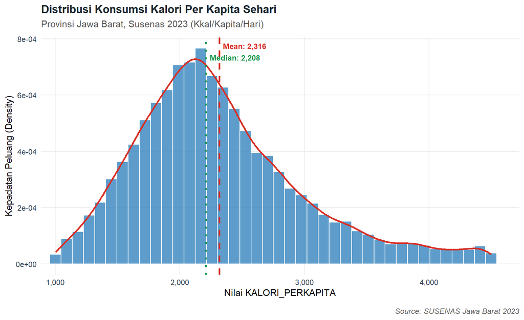

```r
analyze_histogram(
  num_var = "KALORI_PERKAPITA",
  bins = 40,
  add_density = TRUE,
  add_markers = TRUE,
  filter_sql = "KALORI_PERKAPITA <= 5000",
  title = "Distribusi Konsumsi Kalori Per Kapita Sehari",
  subtitle = "Provinsi Jawa Barat, Susenas 2023 (Kkal/Kapita/Hari)"
)
```

# 9 Ringkasan

Seluruh 7 template visualisasi di atas telah terbukti: - **Terenkapsulasi penuh**: Tidak memerlukan modifikasi manual pada data frame. - **Efisiensi komputasi tinggi**: Menggunakan SQLite untuk agregasi awal data jutaan baris. - **Terkoneksi Metadata**: Otomatis menerjemahkan kode BPS menjadi label deskriptif. - **Siap Publikasi**: Otomatis menyematkan judul, subtitle, label sumbu, dan caption sumber SUSENAS Jawa Barat.